# Final Presentation

December 09, 2022 @ 01:15 AM

## Packages Used

I used dplyr for data manipulation and plotting.

```r
library(dplyr)
```

I need readr to load in master file.

```r
library(readr)
```

I need ggplot to create spray chart and heat map.

```r
library(ggplot2)
```

I need scales to format the heat map.

```r
library(scales)
```

## Appalachian State Baseball Dataset

I compiled my dataset using this semester’s TrackMan data collection with Appalachian State Baseball. The dataset was last updated November 6, 2022, for our last scrimmage of the Fall.

**Variables Used in the Dataset:**

- `PitcherTeam`: pitching team
- `BatterTeam`: batting team
- `Bearing`: axis of ball in play (dead center = 0)
- `Distance`: ball in play distance (feet)
- `PlayResult`: outcome of play
- `TaggedHitType`: hit type of ball in play
- `PlateLocSide`: plate location side (feet)
- `PlateLocHeight`: plate location height (feet)
- `ExitSpeed`: velocity of ball off contact (mph)
- `PitchCall`: what happened to the pitch

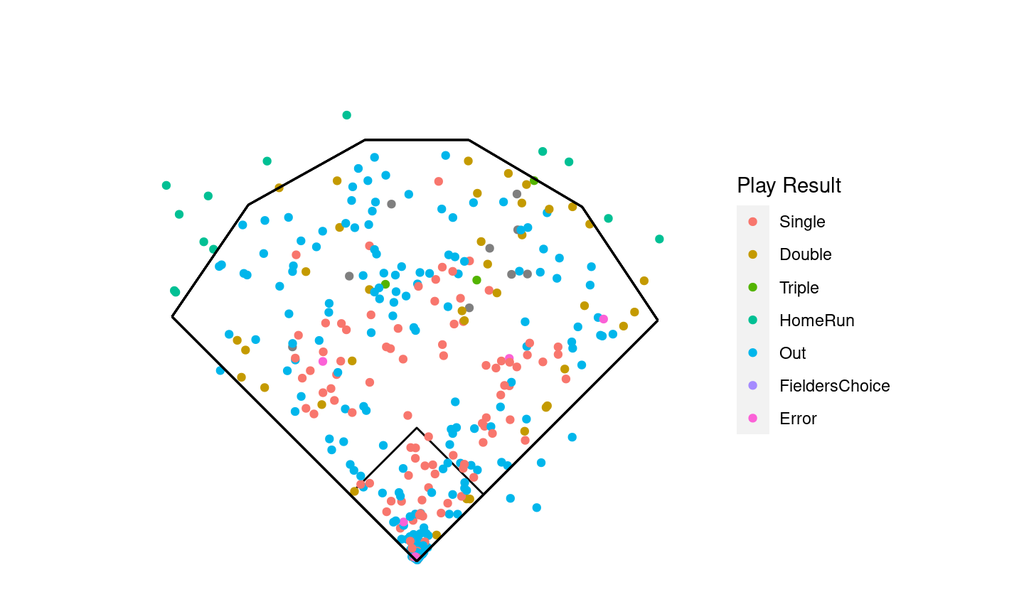

This is a spray chart of every ball in play at Jim and Bettie Smith Stadium, Fall of 2022.

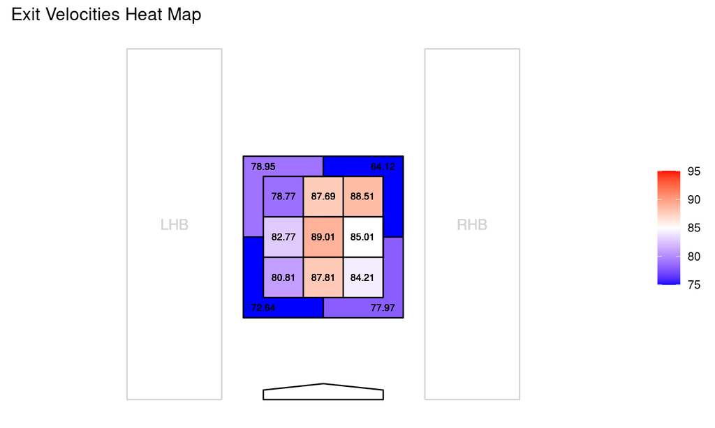

Exit Velocities in each zone. Inner 9 is strike zone. Outer 4 is a ball.